# ECON81815_HW6_Cetin_Belmudes

### Problem Set 6: Incomplete Market with Aggregate uncertainity

##### Hasan Cetin, Lucas Belmudes

#### The Model

- Aggregate production function: $Y_t = s_t F(K_t, L_t)$
- Aggregate shock: $s_t \in \{s_b, s_g\} \; := \; S$ where $s_b$ represents recession and $s_g$ represents boom (i.e. $s_b < s_g$)
- Idiosyncratic labor productivity: $y_t \in \{y_u, y_e\} \; := \; Y = $ where $y_u$ represents unemployement and $y_e$ represents employment (i.e. $y_u < y_e$)
- Transition Matrix: $\pi _{4\text{x}4}$, assume $\pi(y',s'|y,s) > 0, \forall (y,s)$
- Consistency: $\sum_{y'\in Y} \pi(y',s'|y,s) = \pi(s'|s), \forall y \in Y, \forall s,s' \in S$

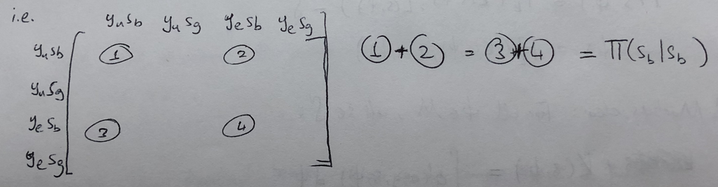

- Assume the fraction of the population in states $y_u, y_e$ is a function of the aggregate shock $s$. Denote it by $\Pi_{s}(y)$
- $\Pi_{s'}(y') = \sum_{y \in Y} \dfrac{\pi(y',s'|y,s)}{\pi(s'|s)}\Pi_{s}(y)$

#### Household Problem

- Individual states: $z = (a,y)$, where $a$ is asset holding, ($z$ is cash in hands state variable)
- Aggregare state variables: $(s, \phi)$, where $\phi$ is the asset distribution (asset distribution is important to determine the price)

Then we can write the Household Problem as:

$$V(\underbrace{a,y}_{z},s,\phi) = \max_{c,a' \geq 0} \left\{u(c) + \beta \underbrace{\sum_{y' \in Y} \sum_{s' \in S} \pi(y',s'|y,s)}_{\mathbb{E}_{(y',s'|y,s)}} V(a',y',s', \phi') \right\}$$$$\text{s.t.}\;\; c + a' = w(s,\phi)y + (1+r(s,\phi))a$$$$\phi' = H(s,\phi,s')$$

where H is the law of motion.

#### Recursive Competitive Equilibrium

- HH value function: $V: ZxSx\mathbb{M} \rightarrow \mathbb{R}$
- HH policy functions: $c,a': ZxSx\mathbb{M} \rightarrow \mathbb{R}$
- Firm policy functions: $K,L: Sx\mathbb{M} \rightarrow \mathbb{R}$
- Aggregate law of motion: $H: Sx\mathbb{M}xS \rightarrow \mathbb{M}$, such that
  1. Given price functions, V attains the supremum of HH problem and policy functions a' and c solves the HH problem.
  2. K,L satisfy: $$r(s,\phi) = F_k(K(s,\phi), L(s,\phi)) - \delta$$ $$w(s,\phi) = F_l(K(s,\phi), L(s,\phi))$$
  3. Markets clear: $$K(s,\phi) = \int a'(a,y,s,\phi)d\phi$$ $$L(s,\phi) = \int y d\phi$$ $$\int c(a,y,s,\phi) + a'(a,y,s,\phi) d\phi = F(K(s,\phi), L(s,\phi)) + (1-\delta) K(s,\phi)$$
  4. Consistency of believes in H holds.

#### Aggregate law of motion

Let $Q_{\phi,s,s'}: Zx\underbrace{\mathbb{B}(Z)}_{\text{Borel set of Z}} \rightarrow [0,1]$ such that:

$$Q_{\phi,s,s'}((a,y), (\mathbb{A}, \mathbb{Y})) = \sum_{y' \in \mathbb{Y}} \pi(y',s'|y,s), \;\;\; \text{if} \; a'(a,y,s,\phi) \in \mathbb{A}$$

i.e. probability of being in $(\mathbb{A}, \mathbb{Y})$ set tomorrow given that you are in state $(a,y)$ today.

Then the aggregate law of motion can be written as:

$$\phi'(\mathbb{A}, \mathbb{Y}) \; := \; H(s,\phi,s')(\mathbb{A}, \mathbb{Y}) = \int Q_{\phi,s,s'}((a,y),(\mathbb{A}, \mathbb{Y})) \phi(da\text{ x }dy)$$

Now, the agent needs to track $\phi$, the asset distribution, to forecast the future prices. But the problem is that $\phi$ is an infinite dimensional beast.

Krussell-Smith's proposal: approximate the distribution $\phi$ with a **finite set of moments.**

KS chose first moment: $\log(K') = a_s + b_s \log(K), \; \text{for } s \in S$

Given estimated $\phi$, we can reduce the HH problem from inifinite dimensional problem to 4 dimensional problem as:

$$V(a,y,s,K) = \max_{c,a' \geq 0} \left\{u(c) + \beta \sum_{y' \in Y} \sum_{s' \in S} \pi(y',s'|y,s) V(a',y',s', K') \right\}$$$$\text{s.t.}\;\; c + a' = w(s,K)y + (1+r(s,K))a$$$$\log(K') = a_s + b_s \log(K), \; \text{for } s \in S$$

#### The algorithm

1. Guess $(a_s, b_s)$
2. Solve HH's consumption-savings problem to find policy function $a'(a,y,s,K)$
3. Simulate N agent T period:
   - Start all agents from some $(a_0, y_0)$ and start the economy from $(s_0, K_0)$
   - Draw random sequences: $\{s_t\}^T$, $\{y_t^i\}^{T,N}$
   - Use the decision rule $a'(a,y,s,K)$ and guessed law of motion $a_s, b_s$ to generate ${a_t^i}^{T,N}$
   - Use the generated ${a_t^i}^{T,N}$ to find aggregate capital simulation $\{K_t\}^T$: $K_t = \dfrac{1}{N}\sum_{i=1}^{N}a_t^i$
4. Run the following regression and estimate $(\alpha_s,\beta_s)$ for $s \in S$:
   - $\log(K') = \alpha_s + \beta_s \log(K)$
   - Note: From the simulation, we have $\{s_t\}^T, \{K_t\}^T$. To find $(\alpha_s,\beta_s)$ for both $s_g, s_b$; divide the K simulation for $s = s_b$ and $s = s_g$ and then do regression for both sequences and update $(\alpha_s,\beta_s), s \in \{s_b, s_g\}$
5. Update your guess to $(\alpha_s,\beta_s)$
6. Iterate this process until $R^2$ of the regression in step 4 is very high (around 0.9999)
7. If $(\alpha_s,\beta_s)$ converges somewhere but you still have low $R^2$ then add higher moments.

```julia
# Used Libraries
using Interpolations, Plots, QuantEcon, Parameters, LinearAlgebra, Optim, Random, Distributions, Roots
using Optim: maximize, maximum, maximizer
```

```julia
# Utility
function u(c)
    if c > 0
        return log(c)
    else
        return -Inf
    end
end
```

```
u (generic function with 1 method)
```

```julia
# Using expanding grid
function expanding_grid(N,min,max,exp_factor)
    init = range(0,1,length = N)
    return min .+ (max-min).*(init.^exp_factor)
end
```

```
expanding_grid (generic function with 1 method)
```

```julia
# Parameters
z_high = 1.01
z_low = 0.99

agg_transition_test = [0.875 0.125;0.125 0.875]

UR_z_high = 0.04
UR_z_low = 0.10



KS_Params = @with_kw (
                u = u,
                α = 0.36,
                β = 0.99, #krusell smith want a quarterly parameterization
                δ = 0.025,
                l = 0.3271, #they set this so that the
                nAggregate = 2,
                z_high = 1.01,
                z_low = 0.99,
                nIdiosyncratic = 2,
                U_high = 0.04,
                U_low = 0.1,
                durgd = 8,
                durbd = 8,
                durug = 1.5,
                durub = 2.5,
                wHome = 0.07,
                aGridMin = 0.0, #these three are the grid for the individual asset holdings
                aGridMax = 35, #this comes from the figures in the working paper
                aGridpoints = 70,
                kGridMin = 10, #KS find an aggregate capital stock of about 11.5 in equilibrium, and use 4-7 grid points in the z direction
                kGridMax = 14,
                kGridpoints = 7,
                θ = 3,
                nHouseholds = 5000,
                nSims = 11000,
                throwout = 1000,
                agg_seed = 5000,
                indiv_seed = 1234
)

params = KS_Params()

function Q(params)
    @unpack U_high,U_low,durug,durub,durgd,durbd = params
    ##aggregate probability
    πgg = 1-1/durgd
    πbb = 1-1/durbd
    πgb = 1-πgg
    πbg = 1-πbb

    ##probability of transitioning out of unemployment
    πgg00 = 1-1/durug
    πbb00 = 1-1/durub
    πgg01 = 1- πgg00
    πbb01 = 1 - πbb00

    ##weird things that we get out of ad hoc restrictions
    πgb00 = 1.25*πbb00
    πbg00 = 0.75*πgg00
    πgb01 = 1- πgb00
    πbg01 = 1 - πbg00

    ##probability of transitioning out of employment
    πgg10 = (U_high - U_high*πgg00)/(1-U_high)
    πbb10 = (U_low - U_low*πbb00)/(1-U_low)
    πgb10 = (U_low - U_high*πgb00)/(1-U_high)
    πbg10 = (U_high - U_low*πbg00)/(1-U_low)

    ##Probability of remaining in employment
    πgg11 = 1 - πgg10
    πgb11 = 1 - πgb10
    πbg11 = 1 - πbg10
    πbb11 = 1 - πbb10

    return [πgg*πgg11 πgg*πgg10 πgb*πgb11 πgb*πgb10;

    πgg*πgg01 πgg*πgg00 πgb*πgb01 πgb*πgb00;

    πbg*πbg11 πbg*πbg10 πbb*πbb11 πbb*πbb10;

    πbg*πbg01 πbg*πbg00 πbb*πbb01 πbb*πbb00]
end

function States(params)
    @unpack z_high,z_low = params
    States = [z_high 1;
              z_high 0;
              z_low 1;
              z_low 0]
    return States
end

work = Q(params)

work2 = States(params)

function Aggregate_Markov(params)
    @unpack Π_gg, Π_bb = params
    Q = [Π_gg 1-Π_gg;1-Π_bb Π_bb]
    states = [1.01,0.99]
    return MarkovChain(Q,states)
end
```

```
Aggregate_Markov (generic function with 1 method)
```

```julia
# Calculating W
function CalculateW(kGrid,params)
    @unpack α,l,nAggregate,z_high,z_low,U_high,U_low = params

    W = zeros(length(kGrid),nAggregate)

    U = [U_high,U_low]
    Z = [z_high,z_low]

    for j in 1:nAggregate
        L = (1-U[j])*l
            for (i,K) in enumerate(kGrid)
                W[i,j] = (1-α)*Z[j]*(K/L)^(α)
            end
    end
    return W
end
```

```
CalculateW (generic function with 1 method)
```

```julia
# Calculating R
function CalculateR(kGrid,params)
    @unpack α,l,nAggregate,z_high,z_low,U_high,U_low = params

    R = zeros(length(kGrid),nAggregate)

    U = [U_high,U_low]
    Z = [z_high,z_low]

    for j in 1:nAggregate
        L = (1-U[j])*l
            for (i,K) in enumerate(kGrid)
                R[i,j] = α*Z[j]*(K/L)^(α-1)
            end
        end
    return R
end
```

```
CalculateR (generic function with 1 method)
```

```julia
function T_Growth(V_growth,σ_growth,labor,aGrid,minA,tMat,shockGrid,maxtol = 1e-8;params)
    @unpack α,β,δ,u,wHome = params

    TV = copy(V_growth)
    Tσ = copy(σ_growth)

    for (z_index,z) in enumerate(shockGrid)

        firstrow = true

        V_knots = V_growth*tMat[z_index,:]
        EV = extrapolate(interpolate(aGrid,V_knots,SteffenMonotonicInterpolation()),Line())

        for (a_index,a) in enumerate(aGrid)

            X = z*(a^α)*(labor^(1-α)) + (1-δ)*a #total resources is everything produced today, plus whatever capital is left over.

            value(a_prime) = u(X-a_prime) + β*EV(a_prime)

            if firstrow

            results = maximize(value,minA,X)
            TV[a_index,z_index] = maximum(results)
            Tσ[a_index,z_index] = maximizer(results)

            else

            results = maximize(value,Tσ[(a_index-1),z_index],X,tolerance = maxtol)
            TV[a_index,z_index] = maximum(results)
            Tσ[a_index,z_index] = maximizer(results)

            end

        end

    end
    dif = maximum(abs.((Tσ .- σ_growth)) ./ (1 .+ abs.(σ_growth)))

    return (TV = TV,Tσ = Tσ,dif = dif)

end
```

```
T_Growth (generic function with 2 methods)
```

```julia
#VFI for the stochastic growth model
function VFI_Growth(labor,tol = 1e-6,maxIter = 2500;params)
    @unpack α,β,δ,u,aGridMin,aGridMax,aGridpoints,wHome,z_high,z_low,θ,nIdiosyncratic = params

    minA = aGridMin + wHome
    aGrid = expanding_grid(aGridpoints,minA,aGridMax,θ)
    zGrid = [z_high,z_low]
    tMat = [0.875 1-0.875;1-0.875 0.875]

    V = zeros(aGridpoints,nIdiosyncratic) #set initial guesses to be zero
    σ = zeros(aGridpoints,nIdiosyncratic)

    dif = 1000
    iter = 1

    if iter <= maxIter
        while dif > tol
        Tv = T_Growth(V,σ,labor,aGrid,minA,tMat,zGrid,1e-8;params)
        V = Tv.TV
        σ = Tv.Tσ
        iter += 1
        dif = Tv.dif
        end
    else
        println("ERROR NO CONVERGENCE")
        return missing
    end

    return (Value = V,Policy = σ,Iterations = iter,CapitalGrid = aGrid,Shocks = zGrid,Transitions = tMat)
end
```

```
VFI_Growth (generic function with 3 methods)
```

```julia
@time test = VFI_Growth(0.9*0.3271,1e-6,2500;params)

plotDims = plot(xLimit = (0,4), yLimit = (0,30));
plotDims = plot(xlimit = (10,15), ylimit = (0,15));
```

```
  0.027836 seconds (50.45 k allocations: 5.311 MiB)
```

```julia
# Interpolation
function CapitalInterpolation(V,kGrid,States,params)
    @unpack aGridpoints,nAggregate,nIdiosyncratic = params

    intps = Matrix{AbstractInterpolation}(undef,aGridpoints,nAggregate*nIdiosyncratic)

    for index in 1:size(States,1)

        for a_idx in 1:aGridpoints
            intps[a_idx,index] = interpolate(kGrid,V[a_idx,:,index],LinearMonotonicInterpolation()) #this puts an interpolation in k at a_idx for shock index
        end

    end

    return intps

end
```

```
CapitalInterpolation (generic function with 1 method)
```

```julia
function V_InterpolatedK(intp,kPrime,aGridpoints,nAggregate,nIdiosyncratic)

    V_kPrime = Matrix{Float64}(undef,aGridpoints,nAggregate*nIdiosyncratic)
    for j in 1:nAggregate*nIdiosyncratic

        for i in 1:aGridpoints
            V_kPrime[i,j] = intp[i,j](kPrime)
        end

    end
    return V_kPrime
end
```

```
V_InterpolatedK (generic function with 1 method)
```

```julia
function T(V,σ,a0,a1,b0,b1,R,W,aGrid,kGrid,States,Q;params)
    @unpack u,α,β,δ,l,wHome,nAggregate,nIdiosyncratic,aGridpoints = params

    TV = copy(V)
    Tσ = copy(σ)

    V_K_Intp = CapitalInterpolation(V,kGrid,States,params)

    for (k_index,k) in enumerate(kGrid) #update over the capital grid

        for index in 1:size(States,1)


            k_prime = exp(a0 + a1*log(k))
            agg_idx = 1

            if index > 2
                k_prime = exp(b0 + b1*log(k))
                agg_idx = 2
            end

            V_kPrime = V_InterpolatedK(V_K_Intp,k_prime,length(aGrid),nAggregate,nIdiosyncratic)


            ϵ = States[index,2]

            V_knots = V_kPrime*Q[index,:]
            EV = extrapolate(interpolate(aGrid,V_knots,FritschButlandMonotonicInterpolation()),Line())

            firstrow = true

            for (a_index,a) in enumerate(aGrid)
                X = (1-δ+R[k_index,agg_idx])*a + W[k_index,agg_idx]*ϵ*l + (1-ϵ)*wHome
                obj(a_prime) = u(X-a_prime) + β*EV(a_prime)

                if firstrow
                    #for the first shock, start at the bottom of the grid
                    results = maximize(obj,0,X) #this tells optim to use brent to search between the minimum of the grid and the amount of output available today
                    TV[a_index,k_index,index] = maximum(results)
                    Tσ[a_index,k_index,index] = maximizer(results)
                    firstrow = false #set the tag to false

                else
                    #search between the max output and the amount chosen for a lower value of a today, at the same wage shock
                    results = maximize(obj, Tσ[(a_index-1),k_index,index],X)
                    TV[a_index,k_index,index] = maximum(results)
                    Tσ[a_index,k_index,index] = maximizer(results)

                end
            end
        end
    end
    #dif = maximum(abs.(TV .- V)./(1 .+ abs.(V))) #convergence is defined in policy function space
    #dif = maximum(abs.(TV-V))
    dif = maximum(abs.(Tσ .- σ)./(1 .+ abs.(Tσ))) #convergence is defined in policy function space
    return (TV = TV,Tσ = Tσ,dif = dif)
end
```

```
T (generic function with 1 method)
```

```julia
# Howard
function PolicyIteration(V,σ,a0,a1,b0,b1,R,W,aGrid,kGrid,States,Q;params)
    @unpack  u,α,β,δ,l,wHome,nAggregate,nIdiosyncratic,aGridpoints, = params

    TV = copy(V)

    V_K_Intp = CapitalInterpolation(V,kGrid,States,params)

    for (k_index,k) in enumerate(kGrid)

        for index in 1:size(States,2)

            k_prime = exp(a0 + a1*log(k))
            agg_idx = 1

            if index > 2
                k_prime = exp(b0 + b1*log(k))
                agg_idx = 2
            end

            V_kPrime = V_InterpolatedK(V_K_Intp,k_prime,length(aGrid),nAggregate,nIdiosyncratic)

            ϵ = States[index,2]

            V_knots = V_kPrime*Q[index,:]
            EV = extrapolate(interpolate(aGrid,V_knots,FritschButlandMonotonicInterpolation()),Line())

            for (a_index,a) in enumerate(aGrid)
                X = (1-δ + R[k_index,agg_idx])*a + W[k_index,agg_idx]*ϵ*l + (1-ϵ)*wHome
                obj(a_prime) = u(X-a_prime) + β*EV(a_prime)

                TV[a_index,k_index,index] = obj(σ[a_index,k_index,index])
            end
        end
    end
    return TV
end
```

```
PolicyIteration (generic function with 1 method)
```

```julia
function V_Initial(tol = 1e-7,maxIter = 2500;params)
    @unpack aGridpoints,kGridpoints,nAggregate,nIdiosyncratic,U_high,U_low,l = params

    V_initial = zeros(aGridpoints,kGridpoints,nAggregate*nIdiosyncratic)#

    V1 = VFI_Growth((1-U_high)*l,tol,maxIter;params)

    for k in 1:kGridpoints
        V_initial[:,k,1] = V1.Value[:,1]
    end

    for k in 1:kGridpoints
        V_initial[:,k,2] = V1.Value[:,2]
    end

    V2 = VFI_Growth((1-U_low)*l,tol,maxIter;params)

    for k in 1:kGridpoints
        V_initial[:,k,3] = V2.Value[:,1]
    end

    for k in 1:kGridpoints
        V_initial[:,k,4] = V2.Value[:,2]
    end

    return V_initial
end
```

```
V_Initial (generic function with 3 methods)
```

```julia
function V_Initial(R,W,aGrid,kGrid;params) #guess that they eat everything
    @unpack β,δ,u,l,wHome,nAggregate,nIdiosyncratic,aGridpoints,kGridpoints = params

    V = zeros(aGridpoints,kGridpoints,nAggregate*nIdiosyncratic)
    for (k_index,k) in enumerate(kGrid)
        index = 1
        for agg_idx in 1:nAggregate

            for idio_idx in 1:nIdiosyncratic
                ϵ = mod(idio_idx,2)

                for (a_index,a) in enumerate(aGrid)
                    V[a_index,k_index,index] = u((1+R[k_index,agg_idx]-δ)*a + W[k_index,agg_idx]*ϵ*l + (1-ϵ)*wHome)
                end
            index += 1
            end
        end
    end
    return V
end
```

```
V_Initial (generic function with 4 methods)
```

```julia
function VFI(a0,a1,b0,b1,nHoward = 1,burnin = 25,tol = 1e-6,maxIter = 2500;params)
    @unpack α,β,δ,u,l,nAggregate,z_high,z_low,nIdiosyncratic,U_high,
    U_low,wHome,
    aGridMin,aGridMax,aGridpoints,
    kGridMin,kGridMax,kGridpoints,
    θ = params

    ##create a grid for individual assets and capital
    aGrid = expanding_grid(aGridpoints,aGridMin,aGridMax,θ)
    kGrid = range(kGridMin,kGridMax,length=kGridpoints)

    ##Create the individual transition matrix
    Q_indiv = Q(params)
    states = States(params)

    ##Create an initial guess, for this, let's just solve the growth problem, and then use those value functions
    #V = zeros(aGridpoints,kGridpoints,nIdiosyncratic*nAggregate)


    ##Calculate R and W once at the start of the loop.
    R = CalculateR(kGrid,params)
    W = CalculateW(kGrid,params)

    ##Create an initial guess
    V =V_Initial(R,W,aGrid,kGrid;params)
    #V = V_Initial(;params)
    σ = ones(aGridpoints,kGridpoints,nIdiosyncratic*nAggregate)

    ##Feed the loop
    dif = 1000
    iter = 1

    while dif > tol
        if iter <= maxIter & iter < burnin
            TV = T(V,σ,a0,a1,b0,b1,R,W,aGrid,kGrid,states,Q_indiv;params)
            σ = TV.Tσ
            V = TV.TV
            dif = TV.dif

            if mod(iter,25) == 0
                println("Iteration ",iter," error is ",dif)
            end

        elseif iter <= maxIter
            TV = T(V,σ,a0,a1,b0,b1,R,W,aGrid,kGrid,states,Q_indiv;params)
            σ = TV.Tσ
            V = TV.TV

            for i in 1:nHoward
                V = PolicyIteration(V,σ,a0,a1,b0,b1,R,W,aGrid,kGrid,states,Q_indiv;params)
            end

            dif = TV.dif

            if mod(iter,25) == 0
                println("Iteration ",iter," error is ",dif)
            end


        else
        println("ERROR NO CONVERGENCE")
        return V
        #return missing
        end
        iter += 1

    end

    return (Value = V,Policy = σ,AssetGrid = aGrid,CapitalGrid = kGrid,Iterations = iter,Difference = dif,Shocks = [z_high,z_low],EmploymentStatus = [1,0],Q_Indiv = Q_indiv,Wage = W)
end
```

```
VFI (generic function with 5 methods)
```

```julia
function PolicyInterpolation(aGrid,kGrid,policyFunctions;params)
    @unpack nAggregate,nIdiosyncratic = params

    policyIntps = Matrix{AbstractInterpolation}(undef,nAggregate,nIdiosyncratic)

    for  i in 1:nAggregate
        for j in 1:nIdiosyncratic
        policyIntps[i,j] = interpolate((aGrid,kGrid),policyFunctions[:,:,i],Gridded(Linear()))
        end
    end

    return policyIntps
end
```

```
PolicyInterpolation (generic function with 1 method)
```

```julia
function K_Simulate(polIntps,employmentPanel,aggStatus;params)
    @unpack nHouseholds,nSims= params
    init_dist = Uniform(0,23)

    global a = rand(init_dist,nHouseholds)

    K = Vector{Float64}(undef,nSims)
    for j in 1:nSims
        K[j] = mean(a)
        println(mean(a))
        for i in 1:nHouseholds
            a[i] = polIntps[aggStatus[1][1],employmentPanel[i,j][1]](a[i],K[j])
        end
    end

    return K
end
```

```
K_Simulate (generic function with 1 method)
```

```julia
function K_Regression(K,aggPath)

    GoodTimes = findall(.==(1),aggPath)
    new = GoodTimes .+ 1
    df1 = DataFrame(K_Prime_G = log.(K[new]),
        K_G = log.(K[GoodTimes]))

    reg1 = lm(@formula(K_Prime_G ~ K_G),df1)

    BadTimes = findall(.==(2),aggPath)
    new = BadTimes .+ 1
    df2 = DataFrame(K_Prime_B = log.(K[new]),
    K_B = log.(K[BadTimes]))

    reg2 = lm(@formula(K_Prime_B ~ K_B),df2)

    r2(reg2)

    return (Good = reg1,Bad = reg2,bR2 = reg(2))
end
```

[output not shown]

```julia
function Probabilities(params)
    @unpack U_high,U_low,durug,durub,durgd,durbd,nAggregate,nIdiosyncratic = params
    ##aggregate probability
    πgg = 1-1/durgd
    πbb = 1-1/durbd
    πgb = 1-πgg
    πbg = 1-πbb

    ##probability of transitioning out of unemployment
    πgg00 = 1-1/durug
    πbb00 = 1-1/durub
    πgg01 = 1- πgg00
    πbb01 = 1 - πbb00

    ##weird things that we get out of ad hoc restrictions
    πgb00 = 1.25*πbb00
    πbg00 = 0.75*πgg00
    πgb01 = 1- πgb00
    πbg01 = 1 - πbg00

    ##probability of transitioning out of employment
    πgg10 = (U_high - U_high*πgg00)/(1-U_high)
    πbb10 = (U_low - U_low*πbb00)/(1-U_low)
    πgb10 = (U_low - U_high*πgb00)/(1-U_high)
    πbg10 = (U_high - U_low*πbg00)/(1-U_low)

    ##Probability of remaining in employment
    πgg11 = 1 - πgg10
    πgb11 = 1 - πgb10
    πbg11 = 1 - πbg10
    πbb11 = 1 - πbb10

    Probabilities = Array{Float64}(undef,nAggregate,nAggregate,nIdiosyncratic)

    Probabilities[1,1,1] = πgg11
    Probabilities[1,2,1] = πgb11
    Probabilities[2,1,1] = πbg11
    Probabilities[2,2,1] = πbb11

    Probabilities[1,1,2] = πgg01
    Probabilities[1,2,2] = πgb01
    Probabilities[2,1,2] = πbg01
    Probabilities[2,2,2] = πbb01

    return Probabilities

end
```

```
Probabilities (generic function with 1 method)
```

```julia
check2 = test.Value

a0_ks = 0.096
a1_ks = 0.962
b0_ks = 0.085
b1_ks = 0.965

@time test = VFI(a0_ks,a1_ks,b0_ks,b1_ks,1,25,1e-6,5000;params)

check = test.Policy
```

```
Iteration 25 error is 0.0012721448878124108
Iteration 50 error is 0.00029837313596922074
Iteration 75 error is 0.00012381593944850067
Iteration 100 error is 6.345356594682662e-5
Iteration 125 error is 3.7377279244561676e-5
Iteration 150 error is 2.336376654902554e-5
Iteration 175 error is 1.5020227204150583e-5
Iteration 200 error is 9.781066709319877e-6
Iteration 225 error is 6.394609640106329e-6
Iteration 250 error is 4.173014349237945e-6
Iteration 275 error is 2.721965037686713e-6
Iteration 300 error is 1.7418075265108428e-6
Iteration 325 error is 1.1086799956050596e-6
  1.435356 seconds (10.29 M allocations: 428.986 MiB, 8.21% gc time)
```

[output not shown]

[output cut: 57 more lines]

[output not shown]

```julia
start = 0
Win = 20
plotDims = plot(xlimit = (start,start+Win),ylimit = (start,start+Win),ticks = range(0,20,length = 9))

kIndex = 4
plot!(plotDims,test.AssetGrid,check[:,kIndex,1],color = :black)
plot!(plotDims,test.AssetGrid,check[:,kIndex,2],color = :red)
plot!(plotDims,test.AssetGrid,test.AssetGrid,color = :blue,linestyle = :dash)

plot!(plotDims,test.AssetGrid,check[:,kIndex,3],color = :blue,linestyle = :dash)
plot!(plotDims,test.AssetGrid,check[:,kIndex,4],color = :green)

plot!(plotDims,test.AssetGrid,check2[:,5,1],color = :blue)
plot!(plotDims,test.AssetGrid,check2[:,6,1],color = :green)
```

[figure not shown]